# DaSEH Lightning Talk

2024-07-31

## Question I am working on/problem I am trying to solve

- Characterizing glyphosate levels in U.S. population
- Relationship with environmental factors like temperature
- What areas of the U.S. have both high heat and high glyphosate usage?

## Planned methods

- Mapping county-level glyphosate usage
- Mapping 85th percentile of county-level mean daily temperatures
- Filtering temperatures where 85th percentile mean daily temperature is 80 or higher
- Mapping glyphosate usage for just those hot counties

## Unexpected problems & how I solved them

- Glyphosate was just total amounts, not corrected for land area! So I mutated the variable to divide glyphosate by area (resulting in kg of glyphosate/km^2).
- I realized 85th percentile mean daily temp over the whole year was not as relevant as temperatures during spray season, so I had to calculate for just the spray season (approximately 1 May to 1 September). HOWEVER, spraying season will vary by growing zone and crop, so for my final analysis I need to tailor this much more.

## Glyphosate Usage in U.S.

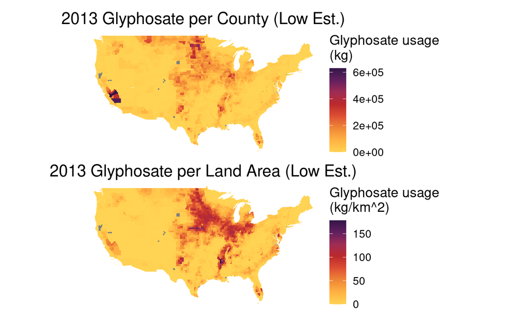

## 85th Percentile Temperatures

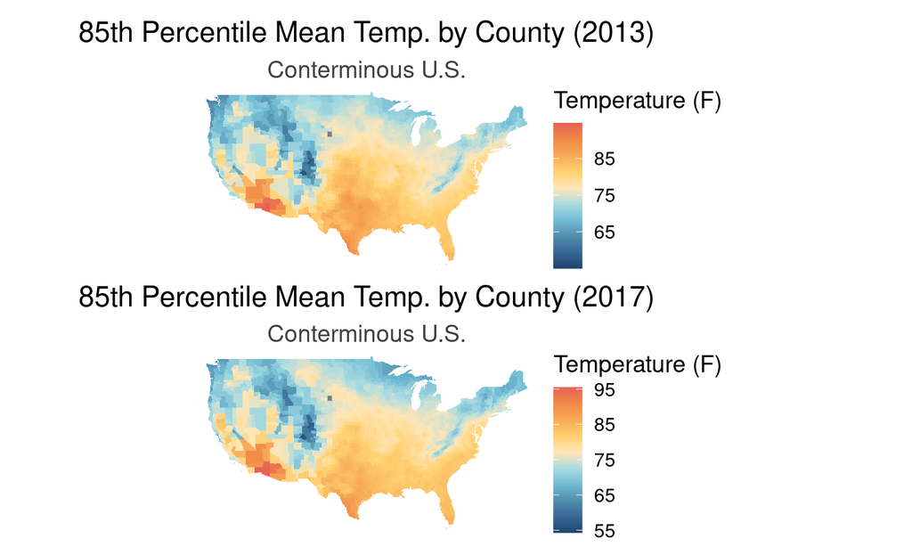

## Glyphosate Usage in the Hottest Counties

- Used leaflet to create a zoomable map!

[interactive chart not shown]